### #TidyTuesday 9-4-18 Week 23

This week’s data is fast food nutritional data. The data can be found [here](https://github.com/rfordatascience/tidytuesday/blob/master/data/2018-09-04/fastfood_calories.csv).

First, let’s load the tidyverse library & read in our data.

```r
library(tidyverse)
library(ggridges)

data <- read_csv("fastfood_calories.csv")
```

For this tutorial, we’re going to do ridgeline plots using the ggrideges package. I want to visualize cholesterol per item for each restaurant. Let’s start by using select() to get the columns we need.

```r
data1 <- data %>%
  select(restaurant, cholesterol)

head(data1)
```

```
## # A tibble: 6 x 2
##   restaurant cholesterol
##   <chr>            <int>
## 1 Mcdonalds           95
## 2 Mcdonalds          130
## 3 Mcdonalds          220
## 4 Mcdonalds          155
## 5 Mcdonalds          120
## 6 Mcdonalds           80
```

Next, let’s do a basic ridgeline plot to see if we’re heading in the right direction.

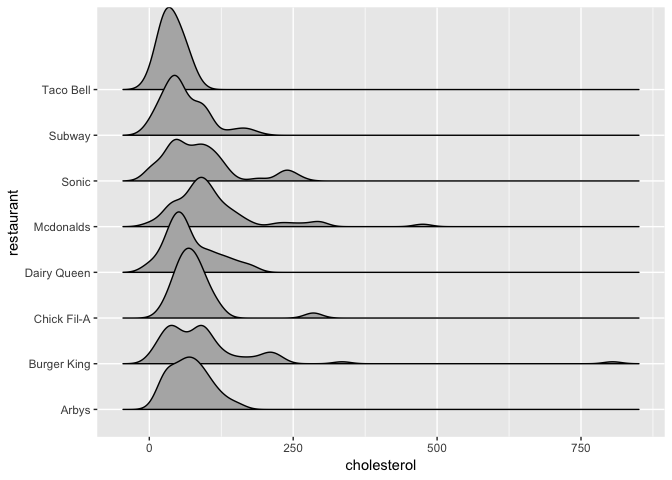

```r
ggplot(data1, aes(cholesterol, restaurant)) +
  geom_density_ridges2()
```

Looks good! To start with let’s add some color. First, we need to add color & fill to the aes call. Color controls the outline of the plot. Fill controls the color inside the plot. If you want to leave the outline black, you can simply leave out the color call. Then we add scale_color_brewer() & scale_fill_brewer(). I picked the “Dark2” palette.

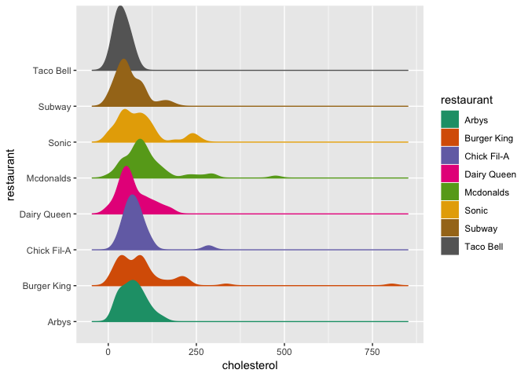

```r
ggplot(data1, aes(cholesterol, restaurant, color = restaurant, fill = restaurant)) +
  geom_density_ridges2() +
  scale_color_brewer(palette="Dark2") +
  scale_fill_brewer(palette="Dark2")
```

Looks better now! Next thing I would like to do is remove the background panel. This will help me figure out other aesthetic choices later. We can remove the background panel using theme().

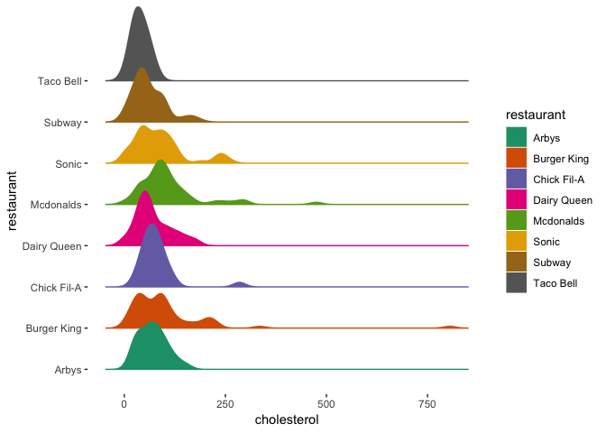

```r
ggplot(data1, aes(cholesterol, restaurant, color = restaurant, fill = restaurant)) +
  geom_density_ridges2() +
  theme(panel.background = element_blank()) +
  scale_color_brewer(palette="Dark2") +
  scale_fill_brewer(palette="Dark2")
```

Much better! Now let’s clean it up a bit. I’d like to remove the legend & the axis titles. Also I’d like to bump up the font on the tick mark labels. We can do all of these by adding to the theme() call.

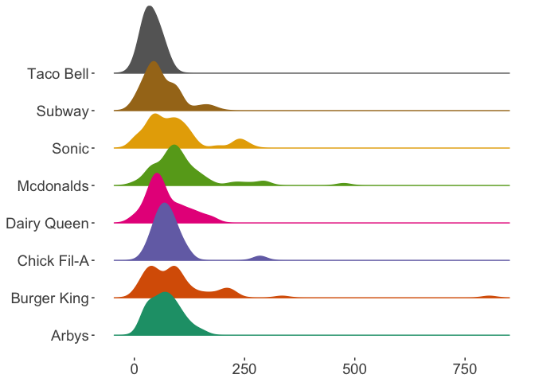

```r
ggplot(data1, aes(cholesterol, restaurant, color = restaurant, fill = restaurant)) +
  geom_density_ridges2() +
  theme(legend.position = "none",
    panel.background = element_blank(),
    axis.title = element_blank(),
    axis.text = element_text(size = 14)) +
  scale_color_brewer(palette="Dark2") +
  scale_fill_brewer(palette="Dark2")
```

It’s looking better! Now let’s remove the tick marks from the y-axis & add x-axis grid lines for clarification. Both of these things can be done in theme.

I also want to reverse the order of the y-axis. We can do this using fct_rev() from the forcats package. The forcats package is included in the tidyverse.

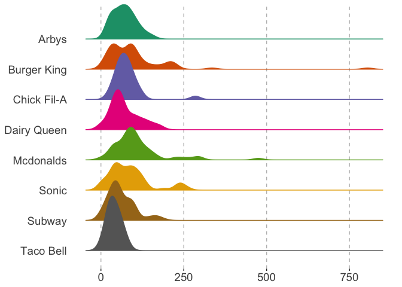

```r
ggplot(data1, aes(cholesterol, fct_rev(restaurant), color = restaurant, fill = restaurant)) +
  geom_density_ridges2() +
  theme(legend.position = "none",
    panel.background = element_blank(),
    axis.title = element_blank(),
    axis.text = element_text(size = 14),
    axis.ticks.y = element_blank(),
    panel.grid.major.x = element_line(color = 'gray', linetype= 'dashed')) +
  scale_color_brewer(palette="Dark2") +
  scale_fill_brewer(palette="Dark2")
```

Another way to go is to remove the “tails” from the plot. If you want to remove the “tails”, you can add rel_min_height to the geom_density_ridges2() call. Removing the “tails” can help visualize some of the outliers that don’t fall into the main curve of the density plot.

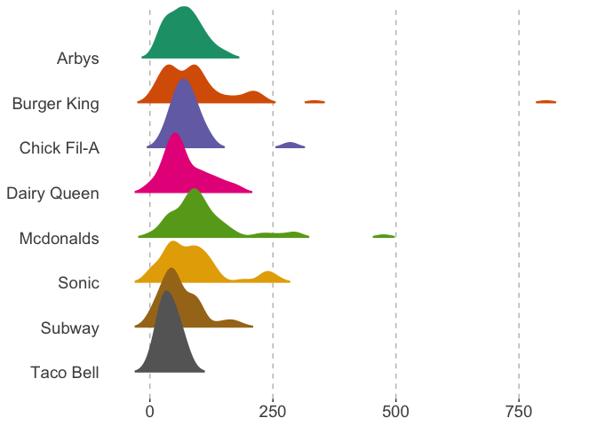

```r
ggplot(data1, aes(cholesterol, fct_rev(restaurant), color = restaurant, fill = restaurant)) +
  geom_density_ridges2(rel_min_height = 0.01) +
  theme(legend.position = "none",
    panel.background = element_blank(),
    axis.title = element_blank(),
    axis.text = element_text(size = 14),
    axis.ticks.y = element_blank(),
    panel.grid.major.x = element_line(color = 'gray', linetype= 'dashed')) +
  scale_color_brewer(palette="Dark2") +
  scale_fill_brewer(palette="Dark2")
```

Any questions or comment, feel free to reach out to me on [Twitter](https://twitter.com/sapo83).